# Mixed models - socioeconomic predictors of forest cover

## Environmental variables

This set initially had two predictor variables - mean elevation and habitat. These variables were intially supposed to be “control” variables, i.e. ensuring that other, non-socioeconomic predictors that would be likely to affect forest cover, were taken into account. I did run some models, diagnostics, and predictions using both variables, but I have decided to drop habitat altogether. This is because the layer I was using for the habitat was the same layer that produced the response - i.e. to get the “forest pixel” layer used in the response, I simply aggregated all of the forest habitat types. Therefore I don’t think it is appropriate to use the same layer as a predictor! That leaves me with mean elevation.

```r
env.m2 <- glmer(ForPix ~ mean_elev + offset(log(areaKM)) + (year|Province/Provcomm),
                family = "poisson", data=dat1)

summary(env.m2)
```

```
## Generalized linear mixed model fit by maximum likelihood (Laplace
##   Approximation) [glmerMod]
##  Family: poisson  ( log )
## Formula: ForPix ~ mean_elev + offset(log(areaKM)) + (year | Province/Provcomm)
##    Data: dat1
##
##      AIC      BIC   logLik deviance df.resid
##  36529.8  36580.7 -18256.9  36513.8     4233
##
## Scaled residuals:
##     Min      1Q  Median      3Q     Max
## -6.1041 -0.0756 -0.0035  0.0230  9.7619
##
## Random effects:
##  Groups            Name        Variance Std.Dev. Corr
##  Provcomm:Province (Intercept) 1.464300 1.21008
##                    year        0.004584 0.06770  0.15
##  Province          (Intercept) 1.382847 1.17594
##                    year        0.000682 0.02612  -0.46
## Number of obs: 4241, groups:  Provcomm:Province, 737; Province, 24
##
## Fixed effects:
##             Estimate Std. Error z value Pr(>|z|)
## (Intercept)  -0.3242     0.2781  -1.166    0.244
## mean_elev     0.4565     0.0604   7.558 4.09e-14 ***
## ---
## Signif. codes:  0 '***' 0.001 '**' 0.01 '*' 0.05 '.' 0.1 ' ' 1
##
## Correlation of Fixed Effects:
##           (Intr)
## mean_elev -0.029
```

The RE variances have decreased slightly compared to previous model sets, suggesting that the elevation predictor is explaning more of the total variance. Elevation appears to have a positive effect on forest pixels and appears significant (very small approximate p value).

### Diagnostics

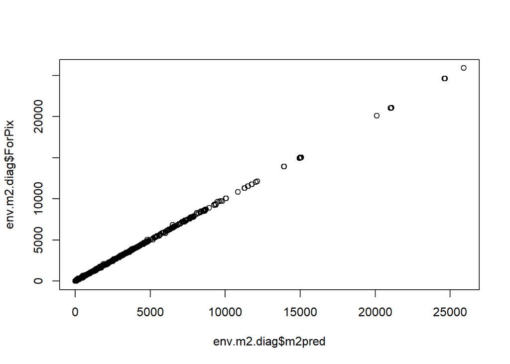

The above plot is the predicted versus observed values, which looks good.

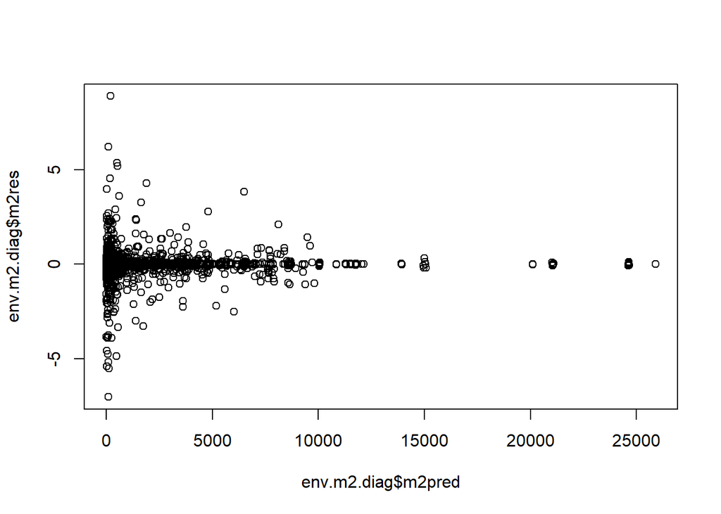

The above plot is the predicted values versus model residuals. Again heteroskedasicity is an issues here - particularly bad a low predicted forest cover. Similar to the popdem models.

Bit more exploration of residuals, but now over the explanatory variable:

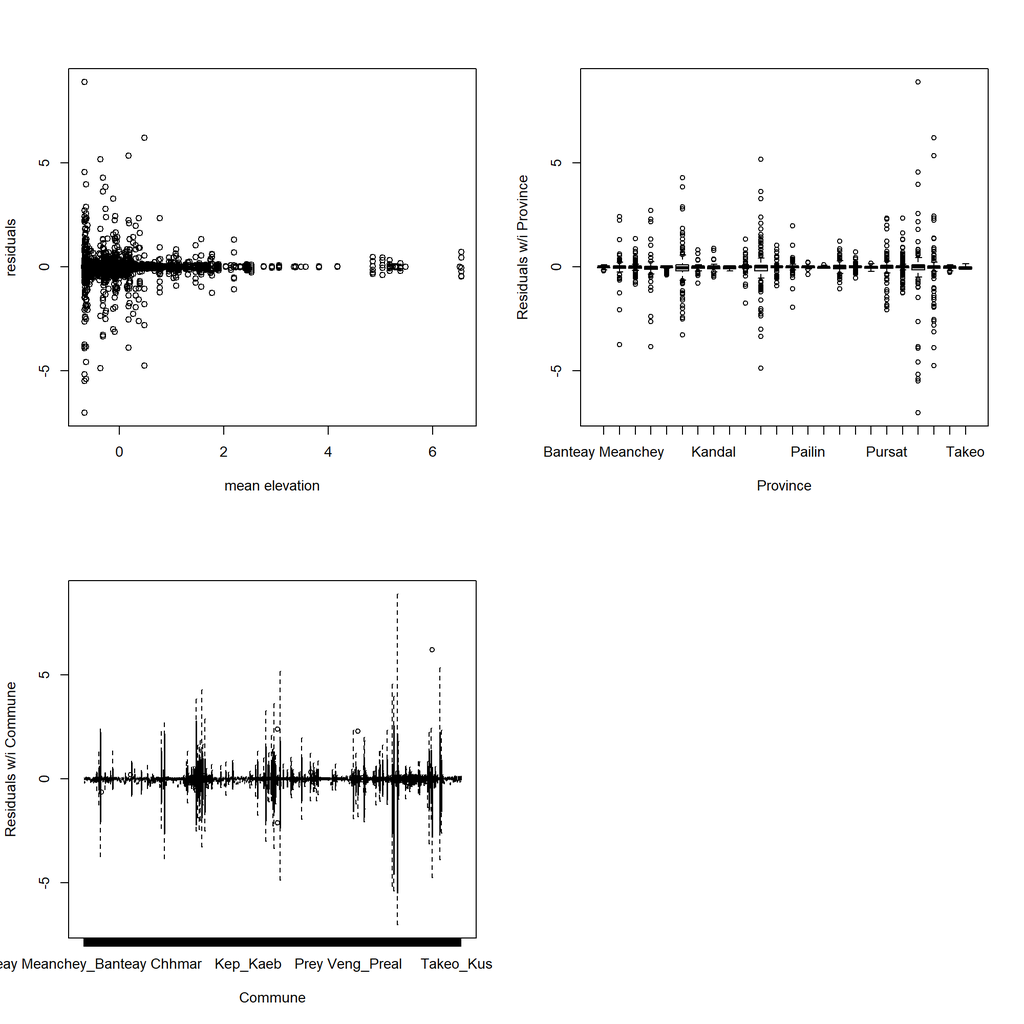

There seems to be a slightly odd pattern in the first plot - it looks like there are certain elevation values that produce large residuals. Zoom in:

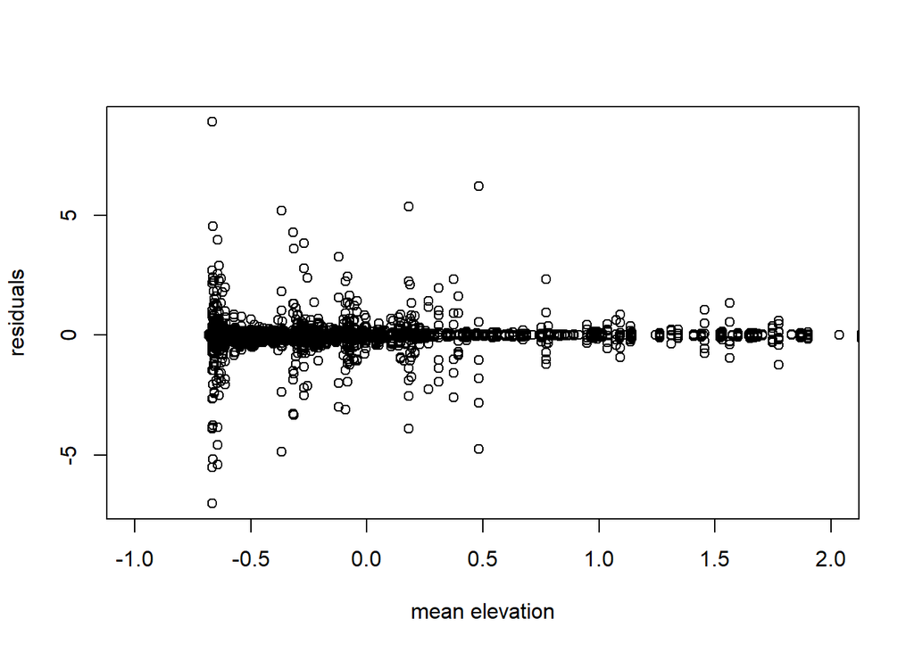

I will take a closer look at the Provinces that have the communes that appear to produce the largest residuals.

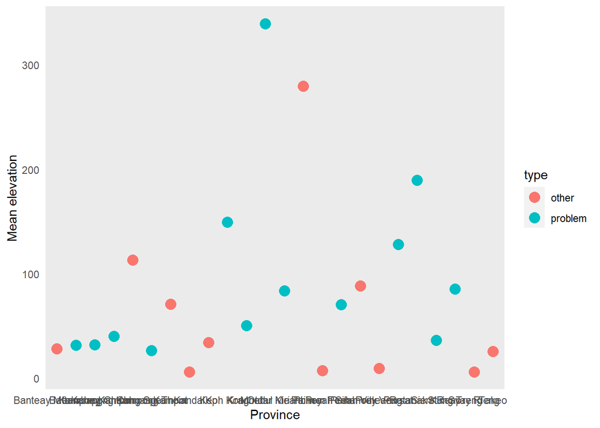

The above plot shows the mean elevation (on the original scale) for each Province, with the “problem” provinces (i.e. the ones with the largest residuals) coloured blue. There is not a striking trend, but the 4 provinces with the lowest mean elevation are all *not* problematic ones.

Now I will pull out the individual communes that have residual values that match the weird pattern and see if there is any other pattern that might explain it.

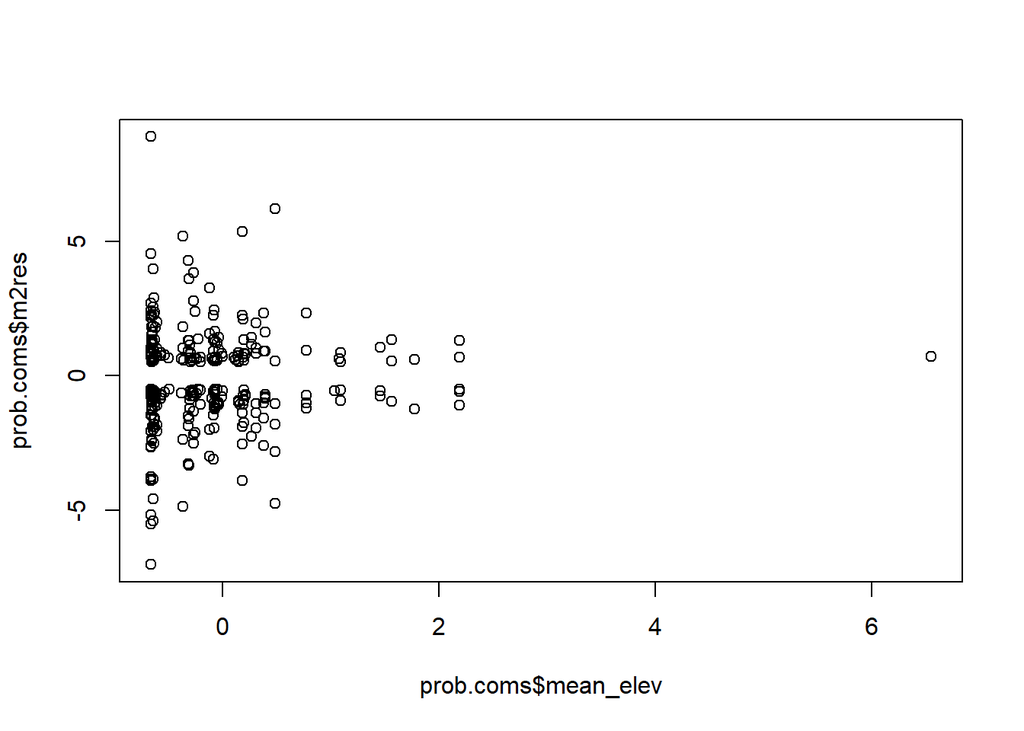

The above plot are the “problem” residuals. These are now the communes with the weird shape. Let’s have a look that these communes and their mean elevation (on the original scale), compared with all other communes:

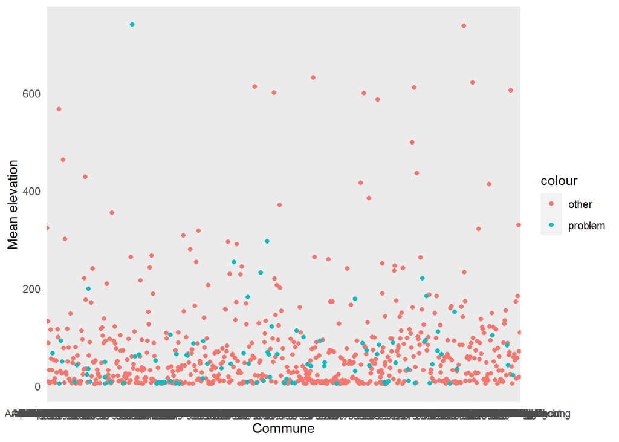

I can’t see an obvious pattern here. The other fixed effect is the offset - areaKM. Perhaps this is the source of the issue:

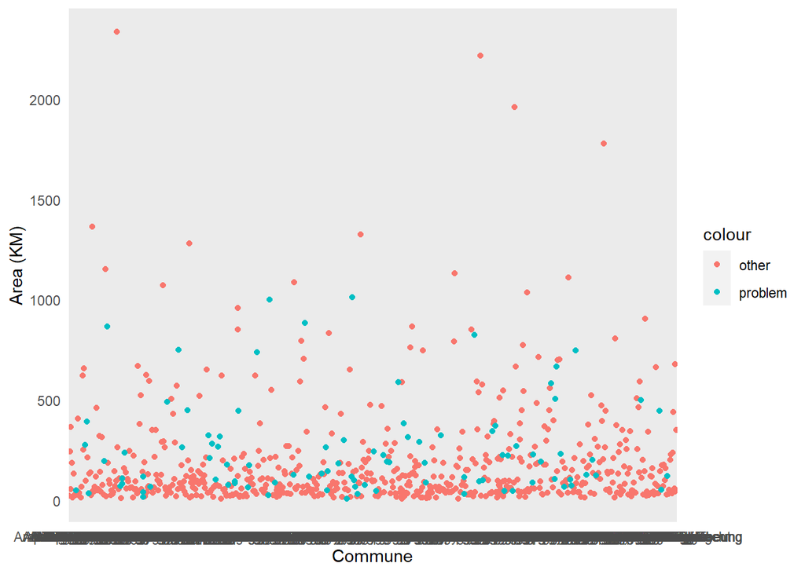

No obvious pattern. Let’s look at the response (ForPix):

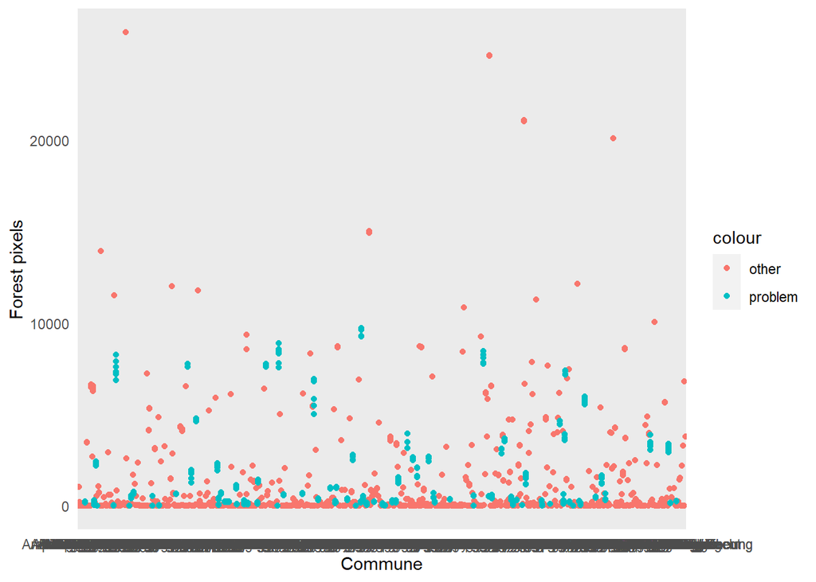

Ok so there is an obvious difference here. The problem communes clearly mostly lose forest over time (vertical lines of dots), whereas the others generally do not (single points). This is the same issue as highlighted in the population demographics model. So the global model does not fit well when communes lose forest over time.

### Predict main effects

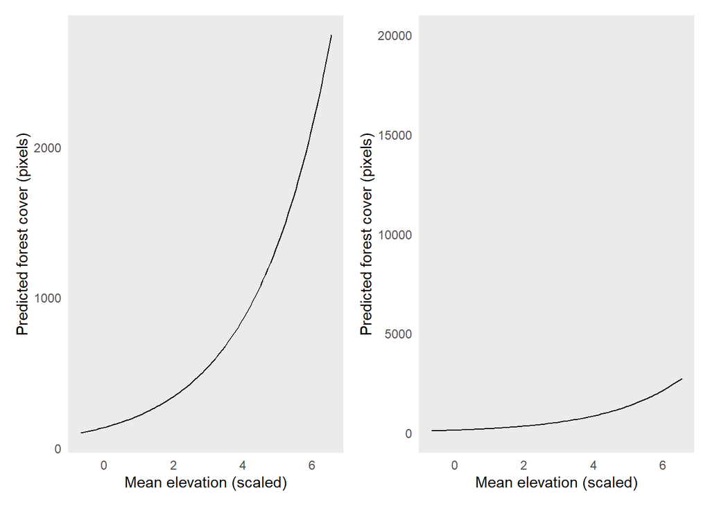

The above two plots show the predicted effects of mean elevation for an “average” commune (i.e. not commune-specific RE’s), with a free y-axis (left) and with a realistic y axis (right). We can see that mean elevation has a positive effect on forest cover. I was expecting this relationship. Most of the highly forested areas in Cambodia are in the provinces with higher elevation.

### Predict for specific commmunes

I will start by predicting for the 4 communes with intercepts closest to 0, the 4 communes with intercepts furthest above 0, and the communes with intercepts furthest below 0.

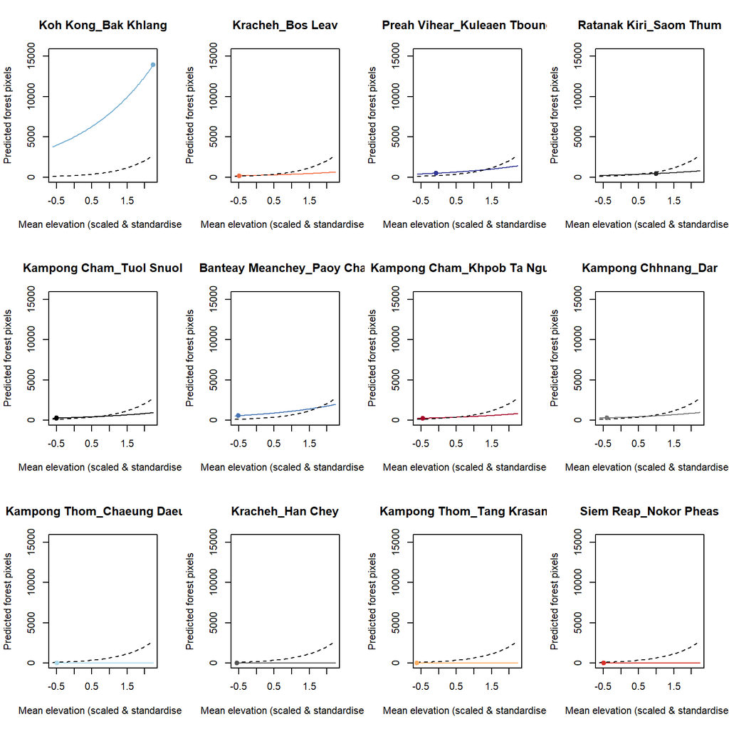

In the above plots, the top row are the communes with intercepts clsoest to 0, middle row are those with intercepts furthest above 0, and bottom row are those with intercepts furthest below 0. The dashed black line is the global model, and the coloured solid lines are the commune-specific predictions. The dots are the actual ForPix ~ mean elevation points for that commune. We can see that as for the population demographics model, the global model predicts poorly for communes with high forest cover, regardless of mean elevation. If a commune has low forest cover, then the global model predicts well for increasing values of elevation, until elevation reaches a scaled value of ~1, after which the model predicts poorly (becasue a commune can’t increase in elevation).

Let’s do the same predictions but for a random set of communes:

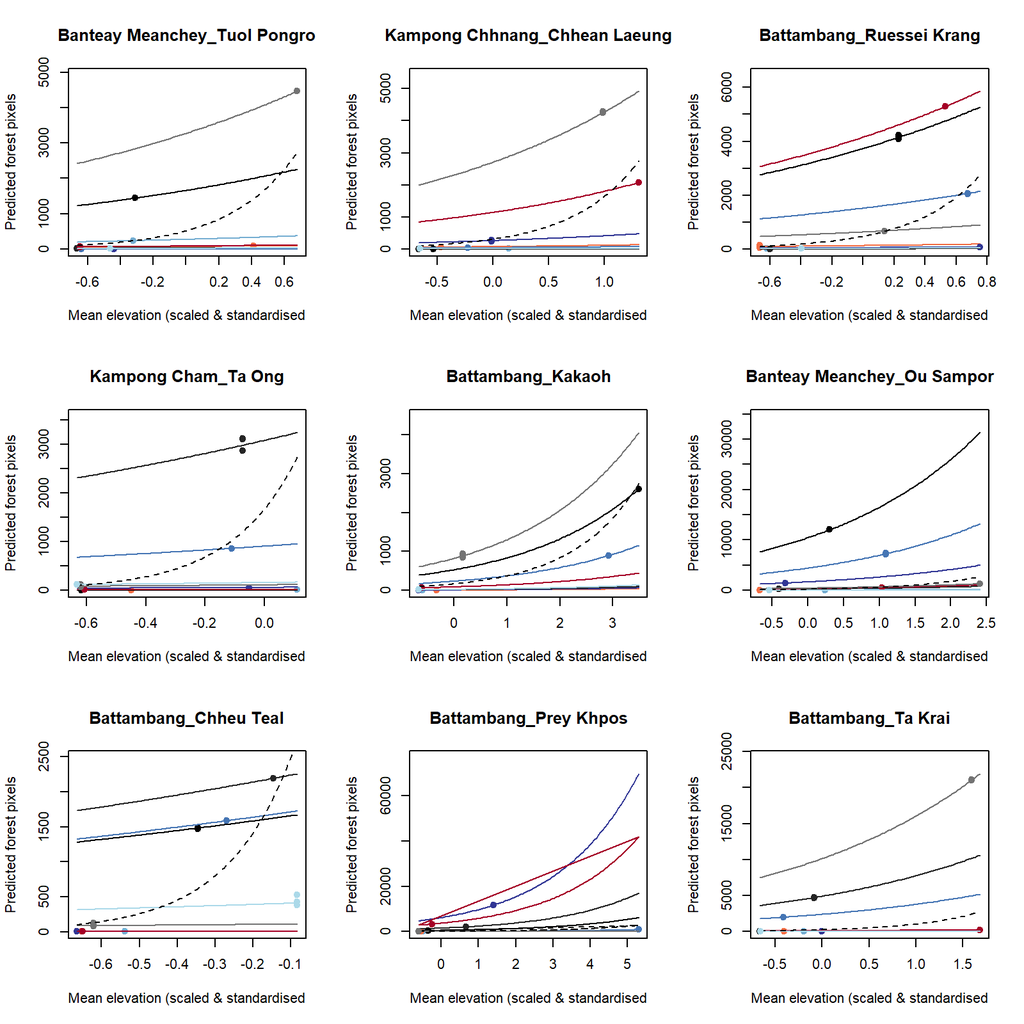

Each plot contains a random sample of 9 communes. Again the black dashed line is the global model. Note the varying y-axes. After running the above random sampling code a few times, it looks as though the global model is good at predicting at low forest cover and low elevation (as with the population density model), as this is where most of the communes sit on the spectrum. It performs ok for communes with higher elevation provided they don’t have too much forest! As soon as the commune has lots of forest or very high elevation, the global model performs badly. It looks as though the commune-specific models predict quite well, provided the communes does not lose forest (as with the population density model).

## Additional human predictor variables

As with the environmental predictor above, these variables were supposed to be “control” variables. The variables included in this set are distance to border (from the centre of the commune), distance to the Provincial Capital (from the centre of the commune), presence of economic land concessions (“elc”, binary), presence of a PA (any kind of PA, binary), PA category (7 levels, including “none”).

```r
hum.m1 <- glmer(ForPix ~ dist_border+dist_provCap+elc+PA+PA_cat+offset(log(areaKM)) +
                  (year|Province/Provcomm), family = "poisson", data=dat1)
```

```
## fixed-effect model matrix is rank deficient so dropping 1 column / coefficient
```

```r
summary(hum.m1)
```

```
## Generalized linear mixed model fit by maximum likelihood (Laplace
##   Approximation) [glmerMod]
##  Family: poisson  ( log )
## Formula:
## ForPix ~ dist_border + dist_provCap + elc + PA + PA_cat + offset(log(areaKM)) +
##     (year | Province/Provcomm)
##    Data: dat1
##
##      AIC      BIC   logLik deviance df.resid
##  36523.6  36625.2 -18245.8  36491.6     4225
##
## Scaled residuals:
##     Min      1Q  Median      3Q     Max
## -6.1126 -0.0828 -0.0034  0.0285  9.7597
##
## Random effects:
##  Groups            Name        Variance  Std.Dev. Corr
##  Provcomm:Province (Intercept) 1.4111833 1.18793
##                    year        0.0046099 0.06790  0.24
##  Province          (Intercept) 1.6972336 1.30278
##                    year        0.0008119 0.02849  -0.10
## Number of obs: 4241, groups:  Provcomm:Province, 737; Province, 24
##
## Fixed effects:
##                Estimate Std. Error z value Pr(>|z|)
## (Intercept)  -0.0048311  0.3854813  -0.013   0.9900
## dist_border   0.2178484  0.0892205   2.442   0.0146 *
## dist_provCap  0.4122782  0.0478197   8.622   <2e-16 ***
## elc1         -0.0001985  0.0024850  -0.080   0.9363
## PA1           0.0684579  0.0589141   1.162   0.2452
## PA_catMULTI   0.0082462  0.0486136   0.170   0.8653
## PA_catNP     -0.0619452  0.0608607  -1.018   0.3088
## PA_catPL      0.0014121  0.0500997   0.028   0.9775
## PA_catRMS     0.3903902  0.5702140   0.685   0.4936
## PA_catWS      0.0296945  0.0605770   0.490   0.6240
## ---
## Signif. codes:  0 '***' 0.001 '**' 0.01 '*' 0.05 '.' 0.1 ' ' 1
##
## Correlation of Fixed Effects:
##             (Intr) dst_br dst_pC elc1   PA1    PA_MUL PA_cNP PA_cPL PA_RMS
## dist_border  0.206
## dist_provCp  0.058  0.178
## elc1        -0.021 -0.008  0.001
## PA1         -0.032 -0.093 -0.035 -0.020
## PA_catMULTI  0.030  0.100  0.005  0.000 -0.791
## PA_catNP     0.028  0.091  0.033  0.024 -0.967  0.765
## PA_catPL     0.030  0.099  0.010  0.027 -0.817  0.966  0.790
## PA_catRMS    0.013  0.075  0.071  0.006 -0.118  0.091  0.115  0.095
## PA_catWS     0.012  0.089 -0.019  0.001 -0.649  0.791  0.628  0.767  0.076
## fit warnings:
## fixed-effect model matrix is rank deficient so dropping 1 column / coefficient
```

Model produces a rank deficiency warning. Interestingly, PA doesn’t appear to look important. This surprises me as you would assume that PAs would be placed in areas with high forest cover. elc doesn’t appear to be important, which is also surprising because I could imagine two scenarios 1) it would have a postive relationship because elc’s were often placed in forested areas, and 2) a negative relationship because the elc’s would have cleared a lot of forest in the areas they were placed. However, during this time period, perhaps not much forest clearing had happened yet. dist_border and dst_provCap appear to be important, with both having a positive effect. dist_provCap I can understand - communes further away from urban centres are likely to be more forested. Not sure yet about dist_border. I think all vars require further investigation.

I will do some quick plots below:

[output not shown]

[output not shown]

[output not shown]

[output not shown]

[output not shown]

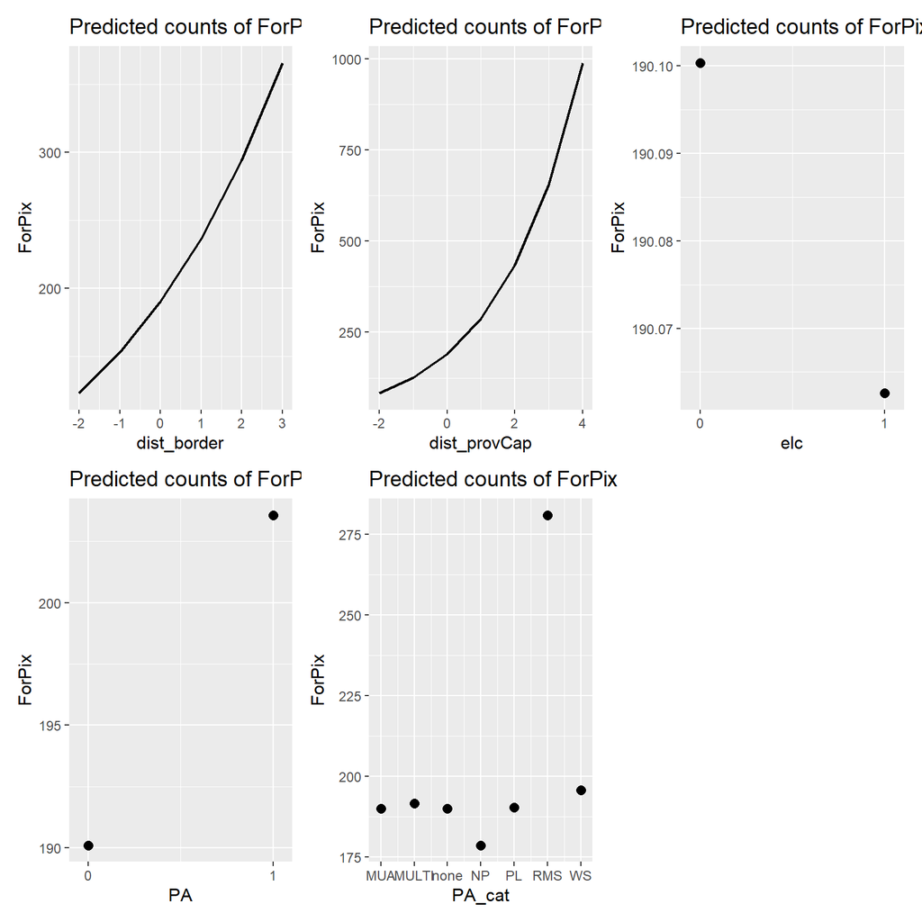

From the quick plots above, it looks like both dist_border and dist_provCap do have a relationship with forest cover. elc does not look promising (note the y axis - difference is tiny), and neither really does PA. Not much difference in predicted forest cover for the different PA categories, apart from the RMS (RAMSAR) level.

I conducted LRT’s and AICc comparisons, and moved forward with predictions and plotting for models with dist_border, dist_provCap, PA and elc. But it became clear that PA and elc did very little, and so I have settled on a model with just dist_border and dist_provCap.

### Diagnostics

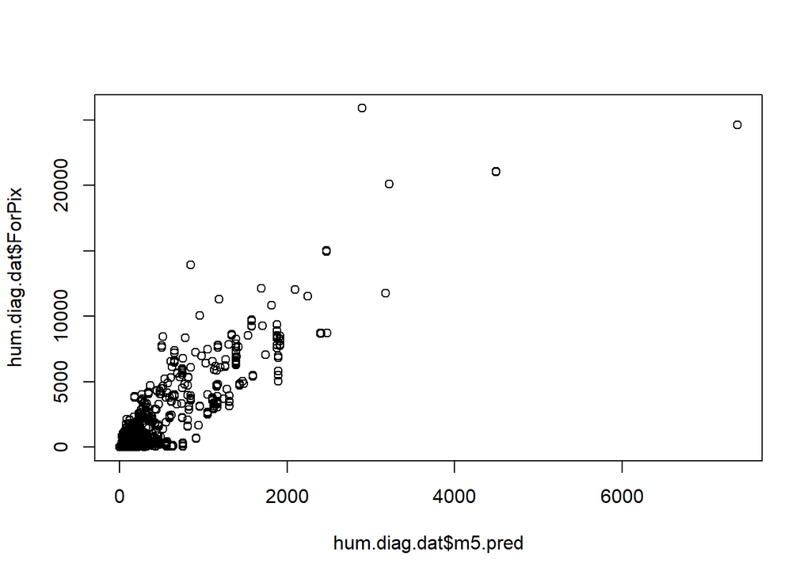

The above plot is the observed values versus the predicted values (from a fully conditional model). This plot is not great - worse than the previous model sets, and it looks like the model is under-predicting by quite a long way.

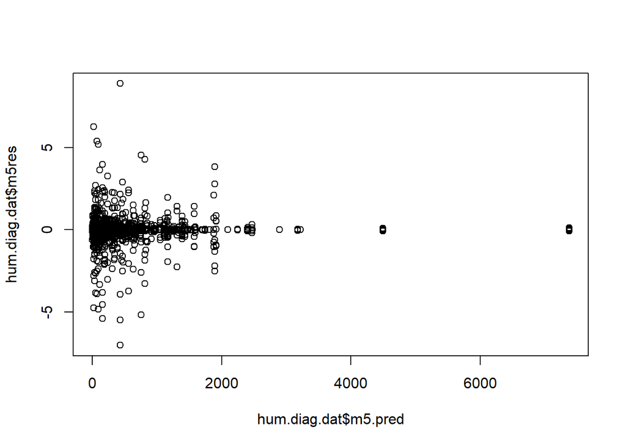

The above plot is the predicted values versus the model residuals. This doesn’t look great. Some outlier large predictions which have small residuals, but a lot of heterogeneity at smaller predicted values. There’s an odd line of residuals just below 2000 (x axis) which suggests there’s one predicted value that is appearing quite a few times? Below I look more closely at the residuals.

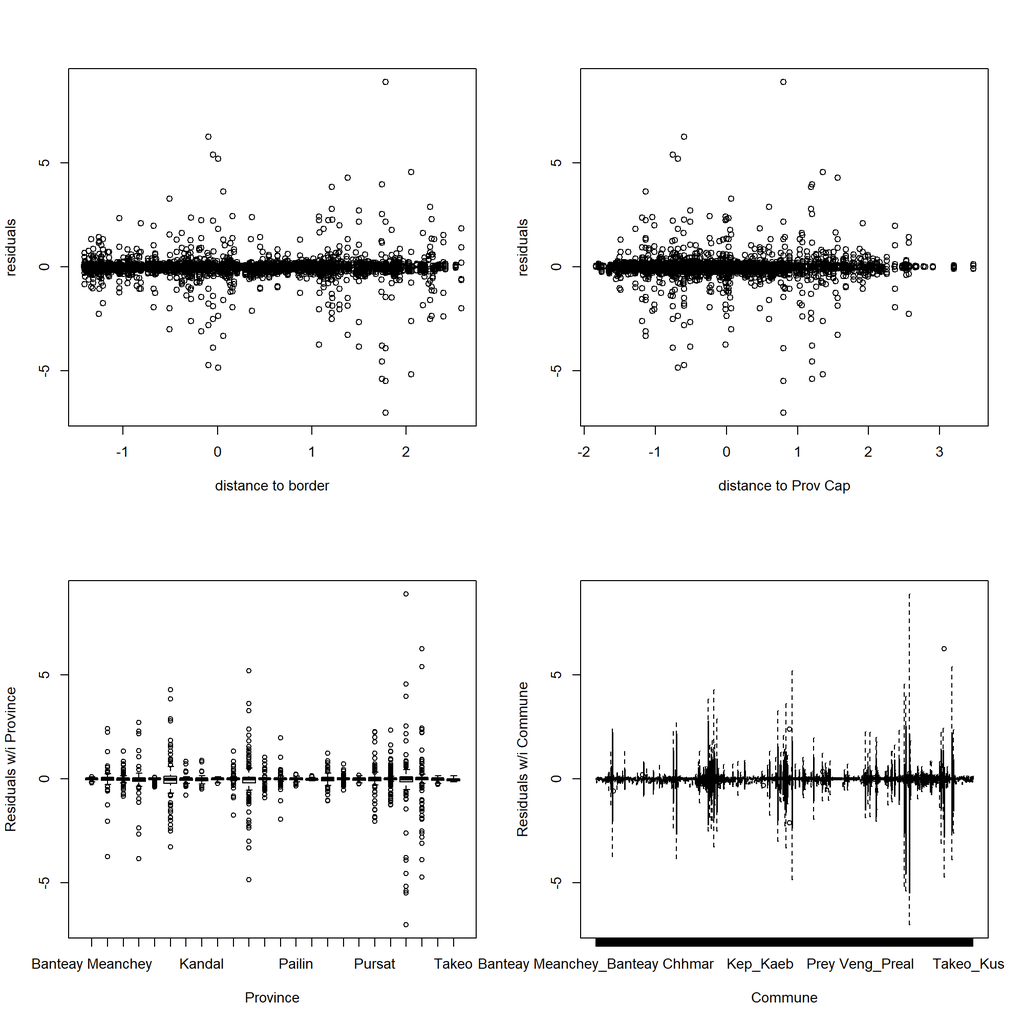

Based on the first two plots, it looks like there’s only a relatively small number of communes that have really large residuals (and there seems to be patterns in these).

Zoom in:

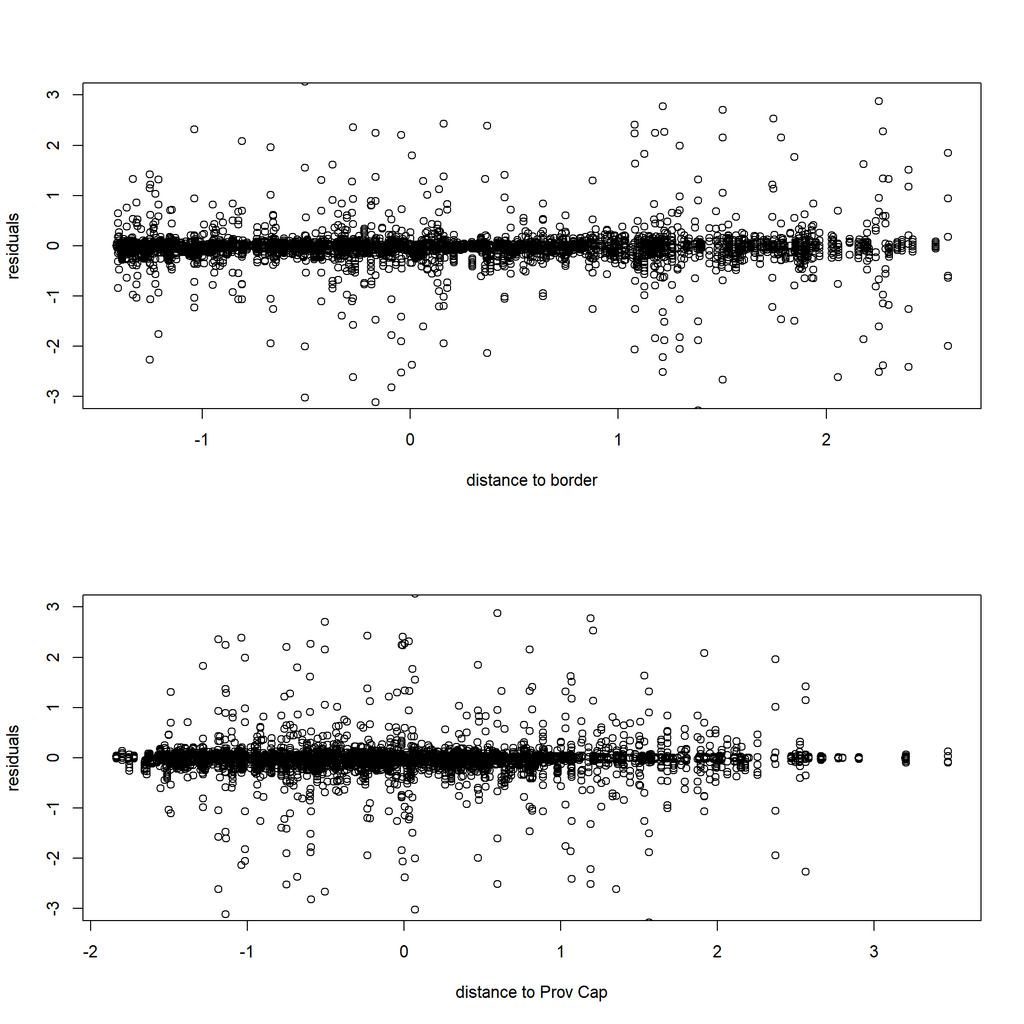

The slightly odd patterns are smaller residuals between 0 and 1 dist_border, and between probably 0 and 0.3 for dist_provCap.

I had a look at which provinces have the larger residuals to see if they match with the problem provinces from the previous model sets. They are Battambang, Kampong Cham, Kampong Chhnanhg, Kampong Thom, Koh Kong, Kracheh, Mondul Kiri, Otdar Meanchey, Pursat, Ratanak Kiri, Siem Reap, Stung Treng. These are the same provinces that are causing issues in the other model sets.

As I have mentioned before, I think these problem communes are the ones that are losing forest over time. I used the raw data to assess which Provinces contain communes that lose some forest over the study period.

```
##  [1] "Kampong Cham"   "Kampong Speu"   "Kampot"         "Koh Kong"
##  [5] "Kracheh"        "Mondul Kiri"    "Otdar Meanchey" "Preah Sihanouk"
##  [9] "Preah Vihear"   "Ratanak Kiri"   "Stung Treng"
```

So this may go some way towards explaining the issues. However, there are still Provinces that lose no forest but are still causing issues, such as Kampong Chhnang and Kampong Thom. I looked more closely at some of the individual communes that had very large residuals.

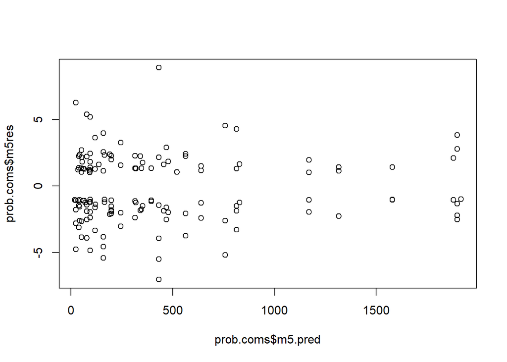

The residuals above are the largest ones. Below, I have split all of the communes into the ones that produced the residuals above, and the rest:

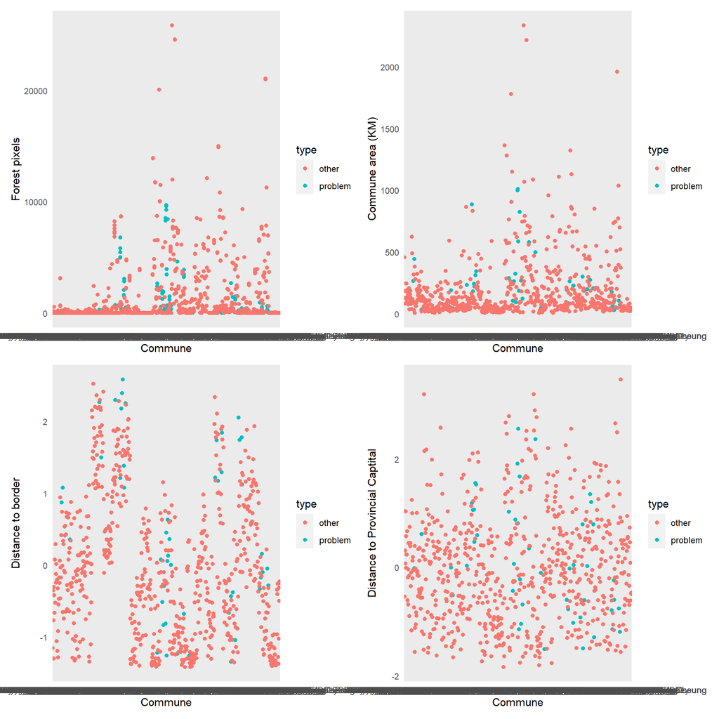

The top left plot is forest pixels per commune, the top right plot is the area (KM) of the communes, the bottom left plot is distance to border, and the bottom right is distance to provincial capital. None of these show an obvious pattern to me - and in fact in the top left plot (forest pixels) the loss of forest over time doesn’t look unique to the problem communes, as it did in the previous sets. The only pattern I can see in these plots is that the problem communes are spatially relatively close and clumped (they are grouped by Province in the dataframe and so if they are plotted near one another on the x axis they are probably in the same Province). But the issues are certainly not unique to a single province, or to a set of communes all with similar characteristics (that I can think of anyway!). So am not sure exactly what the other reasons are for the large residuals in those communes.

### Predict main effects

Below are the predictions for dist_border and dist_provCap from the ‘global’ model.

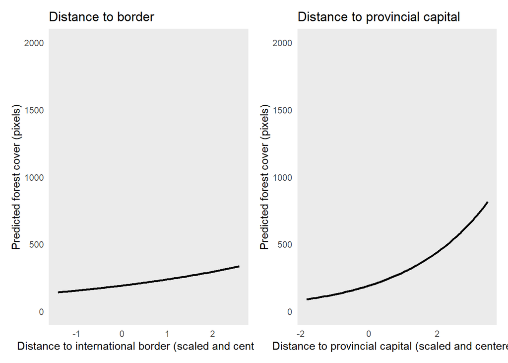

We can see that both predictors have a positive effect on forest cover, and that distance to provincial capital is the stronger effect. The relationship with dist_provCap makes sense - the more rural/remote a communes is, the more likely it is to be forested. Communes that are in or around large urban centres, are unlikely to be heavily forested. The dist_border relationship is more difficult to explain easily. Based on my knowledge of the country I was expecting the opposite - lots of the large PAs are near international borders, whereas much of the central part of the country is farmland. I will need to investigate this further.

### Predict for specific communes

Below I have run predictions for 12 communes - the four with intercepts closest to 0, four with intercepts furthest above 0, and the four with intercepts furthest below 0.

First for dist_border

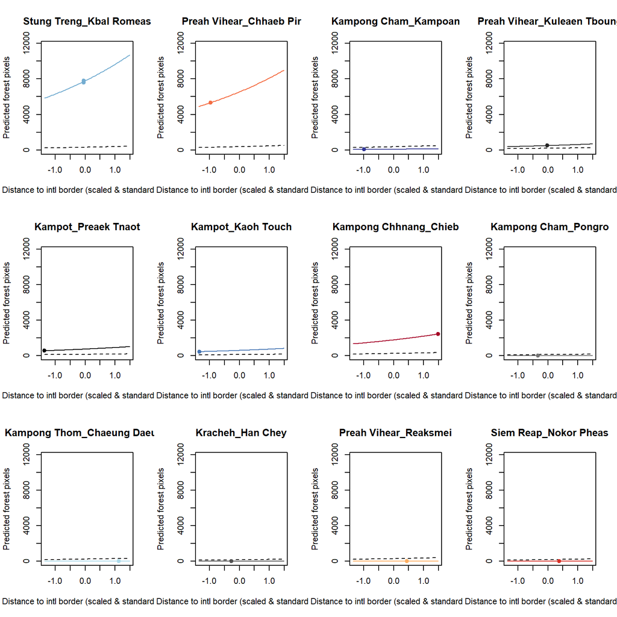

These plots suggest the global model fits poorly for communes with higher forest cover, but fits better for communes with low forest cover, regardless of dist_border, which is much the same as previous models. The global model is better at predicting for communes with intercepts around the global mean, or below it.

Now I will do the same plots but for a random subset of communes.

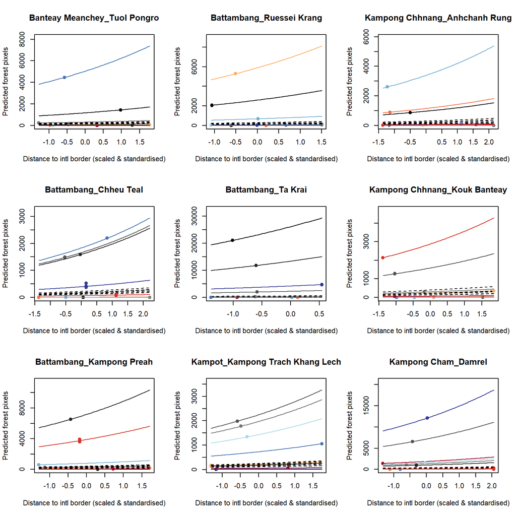

The above plots I think show that again, the commune-specific models are fitting well, provided forest cover doesn’t change.

Below I will do the same predictions and plotting, but for varying dist_provCap. First, I will plot the 12 communes above, below, and around the mean intercept.

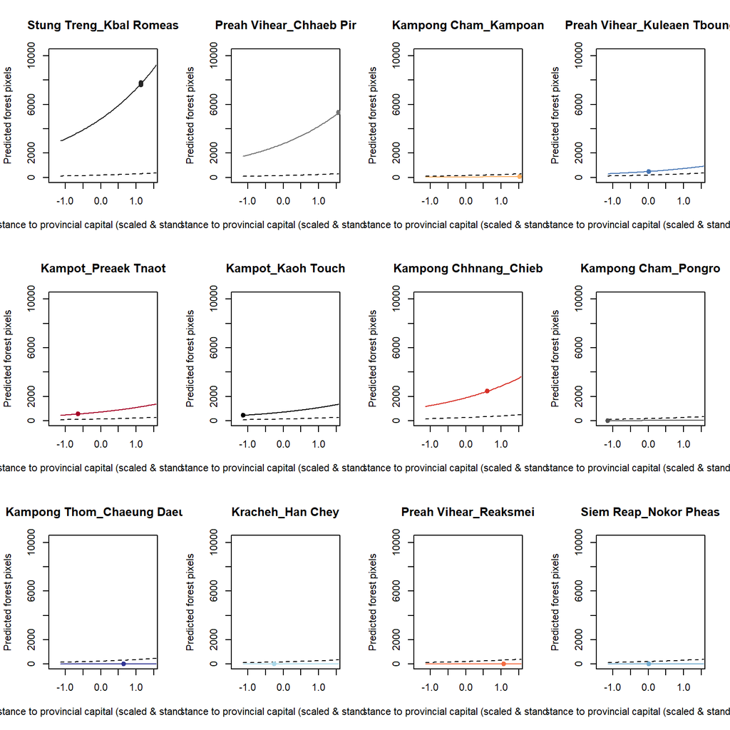

The above plots paint a similar picture to the dist_border plots. Below I will predict and plot for a random subset of communes.

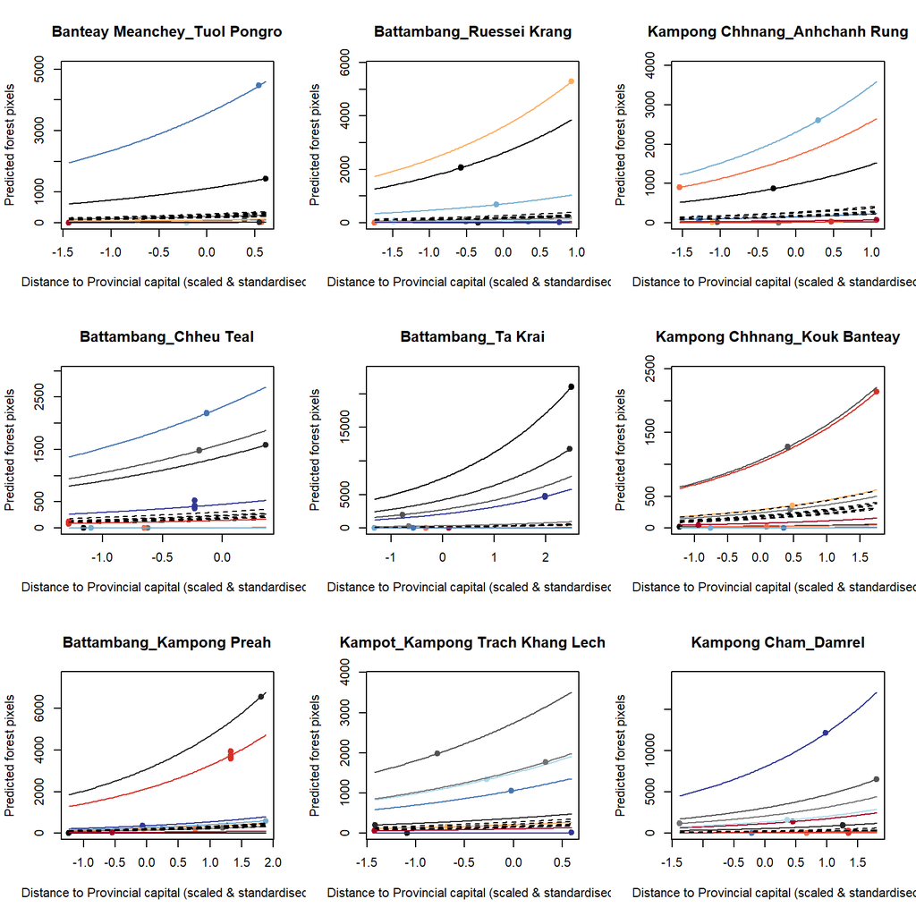